# Practice Problem

Mike LeVan

2025-03-12

# Homework Assignment: Comparing Quantitative Variables with Linear Models

## Introduction

In this assignment, you will practice comparing two different quantitative continuous variables in a built-in dataset in R. You will create scatterplots with linear models using `ggplot2`, identify any possible outliers, calculate the residuals, make a residual plot, and use the linear model to make three predictions, where one of the values is an example of extrapolation.

## Steps

1. **Create a Scatterplot with Linear Model:**
   - Use `ggplot2` to create a scatterplot of the two variables.
   - Add a linear model to the scatterplot using `geom_smooth` with the `lm` method.
2. **Identify Possible Outliers:**
   - Identify any potential outliers in the scatterplot.
3. **Calculate Residuals:**
   - Fit a linear model using `lm()`.
   - Extract the residuals from the model.
4. **Make a Residual Plot:**
   - Create a residual plot using `ggplot2`.
5. **Make Predictions Using the Linear Model:**
   - Use the `predict()` function to make three predictions.
   - Ensure that one of the values used for prediction is an example of extrapolation (a value outside the range of the original data).

## Problem: Cars Dataset - Speed vs Stopping Distance

**Task:** Determine if there is a linear relationship between `speed` and `dist` in the `cars` dataset.

We will first load up the data set and take a look at the first few rows:

```r
# Load ggplot2 and cars dataset
library(ggplot2)
data(cars)

head(cars)
```

```
##   speed dist
## 1     4    2
## 2     4   10
## 3     7    4
## 4     7   22
## 5     8   16
## 6     9   10
```

```r
min(cars$speed)
```

```
## [1] 4
```

```r
max(cars$speed)
```

```
## [1] 25
```

```r
min(cars$dist)
```

```
## [1] 2
```

```r
max(cars$dist)
```

```
## [1] 120
```

From the output of `head(cars)`, we can see that the `cars` dataset contains two variables: `speed` and `dist`.

Let’s make sure we have an outlier in the data set. We will add one using the `rbind( )` function to add a row to the data frame. We will want to add a point that is far from the rest of the data. The speed has values that range between 4 - 25 and the stopping distance has values that range between 2 - 120.

Let’s add a point with a speed of 10 and a stopping distance of 200.

```r
# Add an outlier to the dataset
cars_with_outlier <- rbind(cars, data.frame(speed = 10, dist = 200))
```

Now, we can proceed with the analysis:

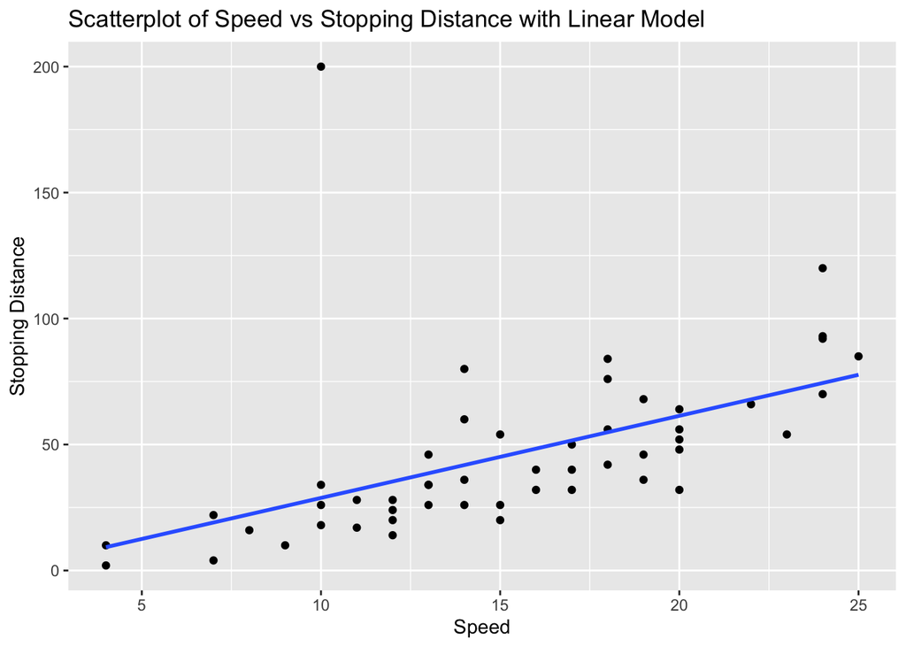

```r
# Scatterplot with linear model
ggplot(cars_with_outlier, aes(x = speed, y = dist)) +
  geom_point() +
  geom_smooth(method = "lm", se = FALSE) +
  labs(title = "Scatterplot of Speed vs Stopping Distance with Linear Model", x = "Speed", y = "Stopping Distance")
```

From the scatterplot, there is a point that is a clear candidate to be an outlier.

At this point we would need to question if we should continue with the analysis or remove the outlier. For the sake of this assignment, we will continue with the analysis.’

We can create the linear model and store it in a variable called `model_cars`. This will allow us to easily see the slope and intercept for the linear model.

```r
# Fit linear model
model_cars <- lm(dist ~ speed, data = cars_with_outlier)

model_cars
```

```
##
## Call:
## lm(formula = dist ~ speed, data = cars_with_outlier)
##
## Coefficients:
## (Intercept)        speed
##      -3.764        3.258
```

Now that we have the model, we are ready to calculate the residuals and make a residual plot.

We will calculate the residuals and store them in a variable called `residuals_cars`.

```r
# Calculate residuals
residuals_cars <- resid(model_cars)

residuals_cars
```

```
##           1           2           3           4           5           6
##  -7.2664872   0.7335128 -15.0394515   2.9605485  -6.2971063 -15.5547611
##           7           8           9          10          11          12
## -10.8124159  -2.8124159   5.1875841 -15.0700707  -4.0700707 -21.3277254
##          13          14          15          16          17          18
## -15.3277254 -11.3277254  -7.3277254 -12.5853802  -4.5853802  -4.5853802
##          19          20          21          22          23          24
##   7.4146198 -15.8430350  -5.8430350  18.1569650  38.1569650 -25.1006898
##          25          26          27          28          29          30
## -19.1006898   8.8993102 -16.3583445  -8.3583445 -19.6159993 -11.6159993
##          31          32          33          34          35          36
##  -1.6159993 -12.8736541   1.1263459  21.1263459  29.1263459 -22.1313089
##          37          38          39          40          41          42
## -12.1313089   9.8686911 -29.3889637 -13.3889637  -9.3889637  -5.3889637
##          43          44          45          46          47          48
##   2.6110363  -1.9042732 -17.1619280  -4.4195828  17.5804172  18.5804172
##          49          50          51
##  45.5804172   7.3227624 171.1875841
```

We can now create the residual plot using ``ggplot( )` where we will keep the same independent variable `speed` and use the `residuals_cars` as the dependent variable.

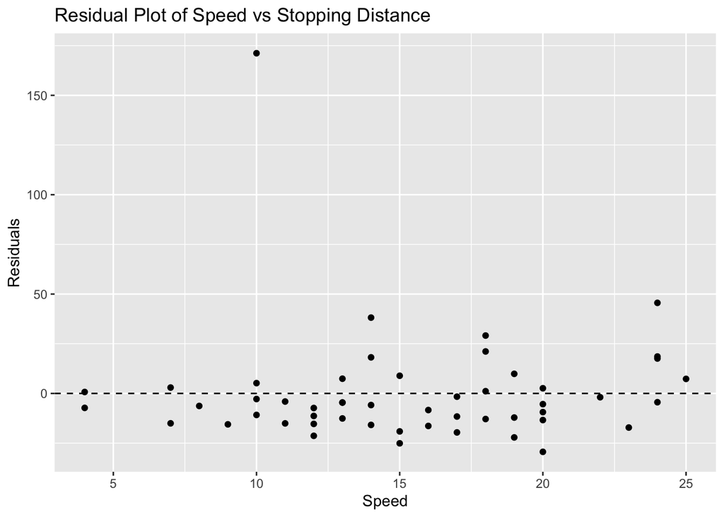

```r
# Residual plot
ggplot(cars_with_outlier, aes(x = speed, y = residuals_cars)) +
  geom_point() +
  geom_hline(yintercept = 0, linetype = "dashed") +
  labs(title = "Residual Plot of Speed vs Stopping Distance", x = "Speed", y = "Residuals")
```

Notice that we have a little more evidence that the point we added is an outlier!

Finally, we can use the linear model to make predictions. We will use the `predict()` function to make three predictions: one for a speed of 10, one for a speed of 15, and one for a speed of 50 (which is an example of extrapolation).

If you recall, we need to use a data frame to make the predictions. We will create a data frame with the `speed` values we want to predict.

```r
# Make predictions
predictions <- predict(model_cars, newdata = data.frame(speed = c(10, 15, 50))) # 50 is extrapolated
predictions
```

```
##         1         2         3
##  28.81242  45.10069 159.11861
```